# Table of Contents

## EDA (Exploratory Data Analysis)

### Descriptive statistics & NULL value check

```python
## check is there any null data in the dataset
df.isnull().sum()
```

```
vote                       0
age                        0
economic.cond.national     0
economic.cond.household    0
Blair                      0
Hague                      0
Europe                     0
political.knowledge        0
gender                     0
dtype: int64
```

There is no null values in the dataset.

```python
## check duplicates in the dataset
df_duplicate = df.duplicated()
print('There are',df_duplicate.sum(), 'records in the dataset which are duplicates')
```

```
There are 8 records in the dataset which are duplicates
```

Let's not **remove these duplicates** at this point in time as there might be posibilities that they are different voters as we dont have any unique identifier.

**Insights:**

- There are **9 variables** in the dataset with **1525 records**
- There is **ZERO** null values in the dataset
- There are **8 recrods** in the dataset are **potential duplicates**. Let's not remove these observations as there might be **posibilities that they are different voters** as we dont have any **unique identifier**
- **Seven** variables are numerical (i.e. age, economic.cond.national, economic.cond.household, Blair, Hague, Europe, political.knowledge)
- **Two** variables are categorical (i.e. vote & gender)
- We have *target(dependent) variable* as **"vote"**

```python
# descriptive statistics summary
df.describe(include='all').T
```

|  | count | unique | top | freq | mean | std | min | 25% | 50% | 75% | max |
| --- | --- | --- | --- | --- | --- | --- | --- | --- | --- | --- | --- |
| vote | 1525 | 2 | Labour | 1063 | NaN | NaN | NaN | NaN | NaN | NaN | NaN |
| age | 1525.0 | NaN | NaN | NaN | 54.182295 | 15.711209 | 24.0 | 41.0 | 53.0 | 67.0 | 93.0 |
| economic.cond.national | 1525.0 | NaN | NaN | NaN | 3.245902 | 0.880969 | 1.0 | 3.0 | 3.0 | 4.0 | 5.0 |
| economic.cond.household | 1525.0 | NaN | NaN | NaN | 3.140328 | 0.929951 | 1.0 | 3.0 | 3.0 | 4.0 | 5.0 |
| Blair | 1525.0 | NaN | NaN | NaN | 3.334426 | 1.174824 | 1.0 | 2.0 | 4.0 | 4.0 | 5.0 |
| Hague | 1525.0 | NaN | NaN | NaN | 2.746885 | 1.230703 | 1.0 | 2.0 | 2.0 | 4.0 | 5.0 |
| Europe | 1525.0 | NaN | NaN | NaN | 6.728525 | 3.297538 | 1.0 | 4.0 | 6.0 | 10.0 | 11.0 |
| political.knowledge | 1525.0 | NaN | NaN | NaN | 1.542295 | 1.083315 | 0.0 | 0.0 | 2.0 | 2.0 | 3.0 |
| gender | 1525 | 2 | female | 812 | NaN | NaN | NaN | NaN | NaN | NaN | NaN |

**Insights:** By looking at the dataset, looks like there are very less outliers in the variables. Further,

*Categorical Variables:*

- `"gender"` of the voters are mainly male and female. It seems female voters contributions are higher than male voters.
- There are mainly two party choice for variable `"vote"` (labour or conservative)> In sample data, we could see labour party has the upper hand then consevative party.

### Skweness and Outlier Check

```python
df.skew() #it gives the details around skewness in the dataset.
```

```
age                        0.144621
economic.cond.national    -0.240453
economic.cond.household   -0.149552
Blair                     -0.535419
Hague                      0.152100
Europe                    -0.135947
political.knowledge       -0.426838
dtype: float64
```

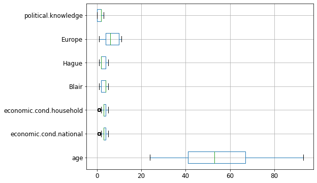

```python
# construct box plot for continuous variables
plt.figure(figsize=(8,6))
df.boxplot(vert=0)
plt.show()
```

**Insights**:

We have **very insignificant `outliers` in the dataset**. So, we would *not be doing any outlier treatment* here.

```python
# define the num_cols and cat_cols to do the next level of inferences
num_cols = ['age', 'economic.cond.national', 'economic.cond.household', 'Blair', 'Hague', 'Europe', 'political.knowledge']
cat_cols = ['vote', 'gender']
```

### Univariate Analysis (Numerical Variables)

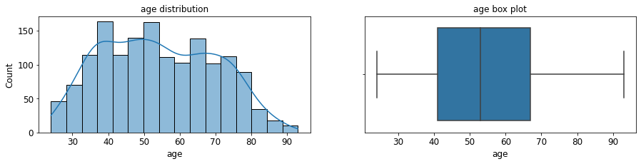

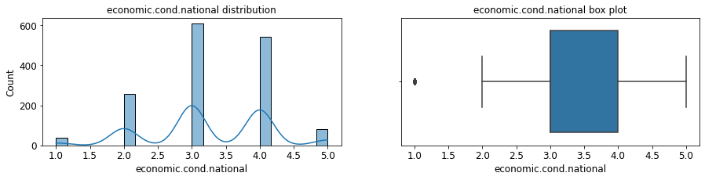

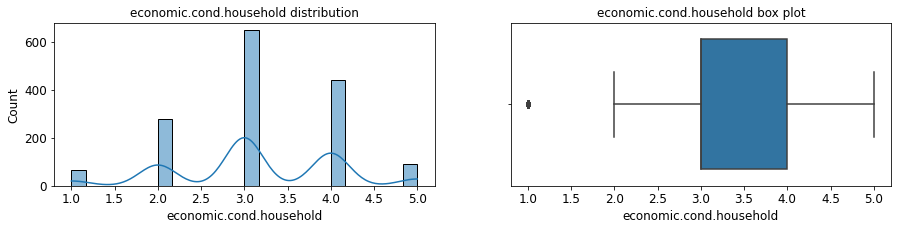

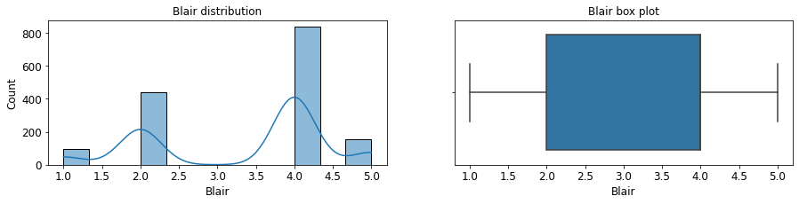

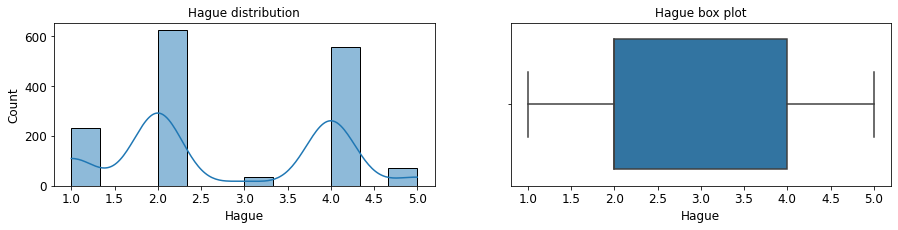

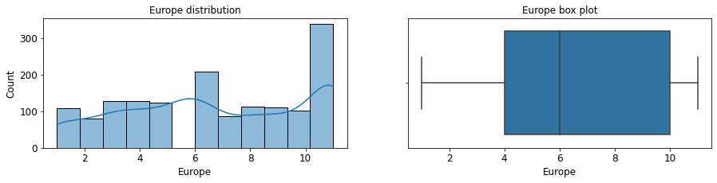

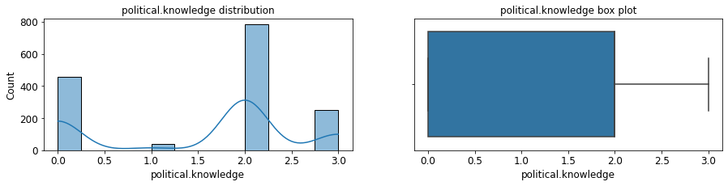

```python
for col in num_cols:
    fig, ax = plt.subplots(nrows=1, ncols=2, figsize=(15,3))
    sns.histplot(x = col, data = df, kde = True, ax=ax[0])
    sns.boxplot(x = col, data = df, ax=ax[1])
    ax[0].title.set_text(col + ' distribution')
    ax[1].title.set_text(col + ' box plot')
    plt.show()
```

**Insights**:

### Univariate Analysis (Categorical Variables)

```
VOTE
```

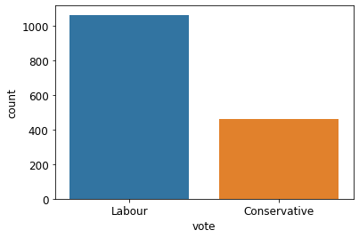

```
GENDER
```

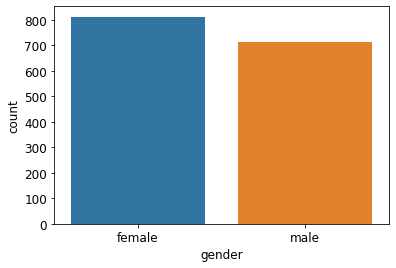

```python
for col in cat_cols:
    print(col.upper())
    sns.countplot(x = col, data= df)
    plt.show()
```

**Insights**:

In Univariate analysis(categoricla variables), we have used count plot and found:

- For `"vote"`, labour party has the higher vote count than conservative.
- For `"gender"`, female voter has the higher voting than male.

### Target Variable Analysis ("vote")

```python
df['vote'].value_counts()
```

```
Labour          1063
Conservative     462
Name: vote, dtype: int64
```

```python
# Ratio
counts = df['vote'].value_counts(normalize=True)
counts
```

```
Labour          0.697049
Conservative    0.302951
Name: vote, dtype: float64
```

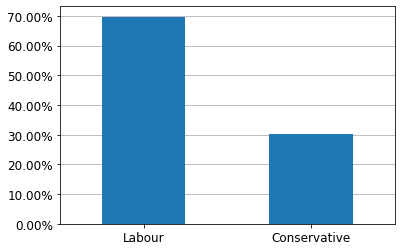

```python
import matplotlib.pyplot as pyp
fig = pyp.figure()
ax = fig.add_subplot(111)

counts.plot(ax=ax,kind='bar', stacked=True, rot=0)
vals = ax.get_yticks()
ax.set_yticklabels(['{:3.2f}%'.format(x*100) for x in vals])
ax.yaxis.grid(True)
ax.set_axisbelow(True)
pyp.show()
```

**Insights:**

- Out of total, there are **1063(~70%) voters** have voted to **labour party** and **462(~30%) voters** have voted to _*conservative party*.
- We have **class imbalance** here. Let's evaluate when build the model

### Bivariate Analysis (Numerical variables vs Numerical variables)

```python
# Covariance

df.cov() # Prints the covariance of each attribute against every other attribute
```

|  | age | economic.cond.national | economic.cond.household | Blair | Hague | Europe | political.knowledge |
| --- | --- | --- | --- | --- | --- | --- | --- |
| age | 246.842075 | 0.256981 | -0.607619 | 0.557762 | 0.669531 | 3.568550 | -0.825301 |
| economic.cond.national | 0.256981 | 0.776107 | 0.283712 | 0.338314 | -0.216589 | -0.608397 | -0.022546 |
| economic.cond.household | -0.607619 | 0.283712 | 0.864810 | 0.235192 | -0.116689 | -0.352299 | -0.038091 |
| Blair | 0.557762 | 0.338314 | 0.235192 | 1.380212 | -0.351648 | -1.147341 | -0.026621 |
| Hague | 0.669531 | -0.216589 | -0.116689 | -0.351648 | 1.514631 | 1.166149 | -0.040469 |
| Europe | 3.568550 | -0.608397 | -0.352299 | -1.147341 | 1.166149 | 10.873759 | -0.544285 |
| political.knowledge | -0.825301 | -0.022546 | -0.038091 | -0.026621 | -0.040469 | -0.544285 | 1.173571 |

```python
# correlation
cor = df.corr()  # prints the correlation coefficient between every pair of attributes
cor
```

|  | age | economic.cond.national | economic.cond.household | Blair | Hague | Europe | political.knowledge |
| --- | --- | --- | --- | --- | --- | --- | --- |
| age | 1.000000 | 0.018567 | -0.041587 | 0.030218 | 0.034626 | 0.068880 | -0.048490 |
| economic.cond.national | 0.018567 | 1.000000 | 0.346303 | 0.326878 | -0.199766 | -0.209429 | -0.023624 |
| economic.cond.household | -0.041587 | 0.346303 | 1.000000 | 0.215273 | -0.101956 | -0.114885 | -0.037810 |
| Blair | 0.030218 | 0.326878 | 0.215273 | 1.000000 | -0.243210 | -0.296162 | -0.020917 |
| Hague | 0.034626 | -0.199766 | -0.101956 | -0.243210 | 1.000000 | 0.287350 | -0.030354 |
| Europe | 0.068880 | -0.209429 | -0.114885 | -0.296162 | 0.287350 | 1.000000 | -0.152364 |
| political.knowledge | -0.048490 | -0.023624 | -0.037810 | -0.020917 | -0.030354 | -0.152364 | 1.000000 |

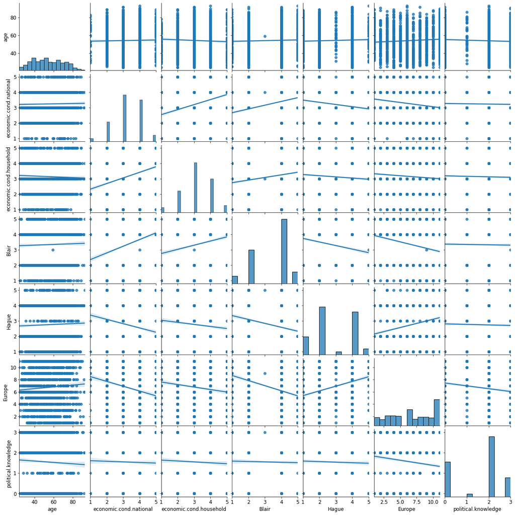

```python
# scatter plot
sns.pairplot(df,kind='reg')
```

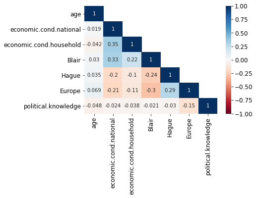

```python
# Heatmap view
sns.heatmap(df[num_cols].corr(),annot=True,vmax=1,vmin=-1,cmap='RdBu',
            mask=np.triu(df[num_cols].corr(),+1))
```

```python
#Highly correlated variables
c = cor.abs()

# Unstack the correlation matrix
s = c.unstack()

#Filter to exclude values of 1
s = s[s != 1]

# Sort descending to find the highly correlated variables
so = s.sort_values(kind="quicksort", ascending=False)[:15]
so.round(2)
```

```
economic.cond.household  economic.cond.national     0.35
economic.cond.national   economic.cond.household    0.35
                         Blair                      0.33
Blair                    economic.cond.national     0.33
                         Europe                     0.30
Europe                   Blair                      0.30
                         Hague                      0.29
Hague                    Europe                     0.29
                         Blair                      0.24
Blair                    Hague                      0.24
economic.cond.household  Blair                      0.22
Blair                    economic.cond.household    0.22
economic.cond.national   Europe                     0.21
Europe                   economic.cond.national     0.21
economic.cond.national   Hague                      0.20
dtype: float64
```

**Insights:**

In Bivariate analysis(Numerical variables), we have used **scatter plot & heatmap** and found:

- In scatter plot and heat map both stats that **none of the variables shows the strong relationship**.

### Bivariate Analysis (Categorical variables vs Categorical variables)

```
GENDER
```

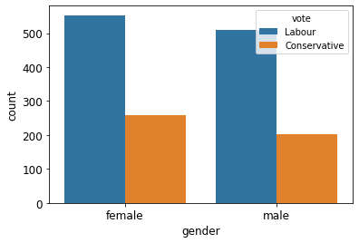

```python
for col in cat_cols[-1:]:
    print(col.upper())
    sns.countplot(x = col, hue = 'vote', data= df)
    plt.show()
```

**Insights:**

In Bivariate analysis(categorical variables), we have used countplot and found:

- Female voters are higher than male voters further inclination towards 'labour party' is higher in both (i.e. female and male).

### Bivariate Analysis (Variable ('gender') vs Numerical variables)

```
AGE
```

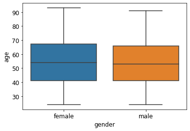

```
ECONOMIC.COND.NATIONAL
```

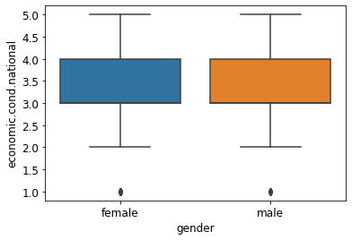

```
ECONOMIC.COND.HOUSEHOLD
```

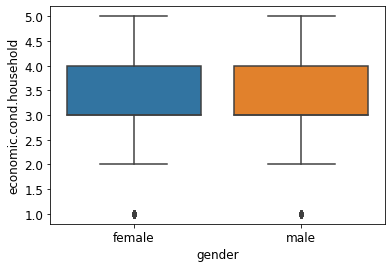

```
BLAIR
```

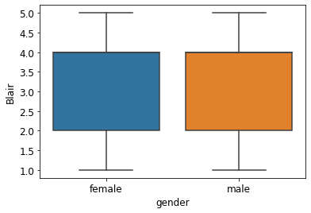

```
HAGUE
```

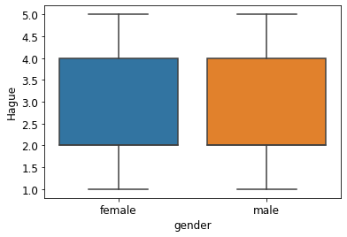

```
EUROPE
```

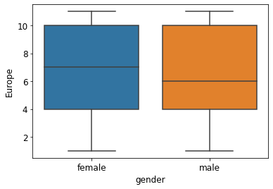

```
POLITICAL.KNOWLEDGE
```

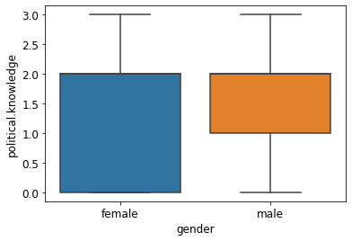

```python
for col in num_cols:
    print(col.upper())
    sns.boxplot(x = 'gender', y = col, data= df, orient= 'v')
    plt.show()
```

### Bivariate Analysis (Target variable ('vote') vs Numerical variables)

```
AGE
```

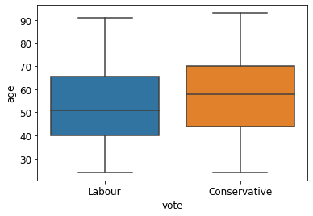

```
ECONOMIC.COND.NATIONAL
```

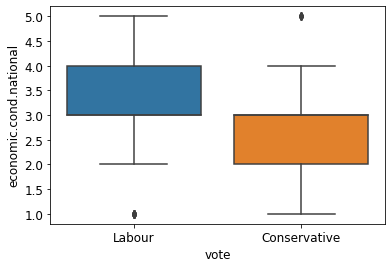

```
ECONOMIC.COND.HOUSEHOLD
```

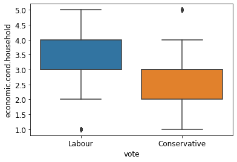

```
BLAIR
```

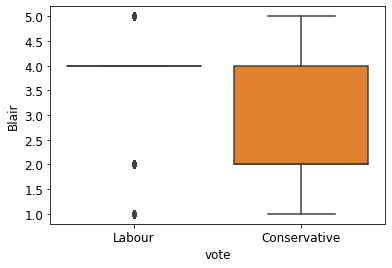

```
HAGUE
```

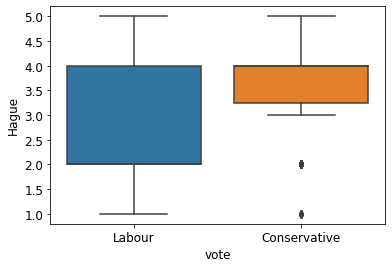

```
EUROPE
```

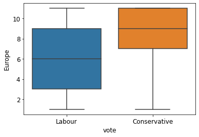

```
POLITICAL.KNOWLEDGE
```

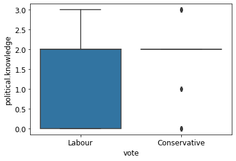

```python
for col in num_cols:
    print(col.upper())
    sns.boxplot(x = 'vote', y = col, data= df, orient= 'v')
    plt.show()
```

# Data Preparation

## Convert text to numbers

```python
df = pd.get_dummies(df, drop_first=True)
df.head(2)
```

|  | age | economic.cond.national | economic.cond.household | Blair | Hague | Europe | political.knowledge | vote_Labour | gender_male |
| --- | --- | --- | --- | --- | --- | --- | --- | --- | --- |
| 0 | 43 | 3 | 3 | 4 | 1 | 2 | 2 | 1 | 0 |
| 1 | 36 | 4 | 4 | 4 | 4 | 5 | 2 | 1 | 1 |

```python
df.rename(columns={'vote_Labour': 'vote_labour'}, inplace=True)
```

**Note:** Here, we could refer **"vote_labour = 1"** to vote was given to **"labour party"** and **"vote_labour = 0"** means vote given to **"conservative party"**

## Train - Test Split

```python
# define independent and dependent variables
X = df.drop('vote_labour', axis=1)
y = df['vote_labour']
```

```python
# train and test split with 70/30 ratio and used stratify to allocate same % of vote_labour class into train and test.
X_train, X_test, y_train, y_test = train_test_split(X, y, test_size = 0.30, random_state = 1, stratify = y)
```

```python
# Checking the dimensions of the training and test data
print('X_train:',X_train.shape)
print('Y_train:',y_train.shape)
print('X_test:',X_test.shape)
print('Y_test:',y_test.shape)
print('Total Count:',df.shape[0])
```

```
X_train: (1067, 8)
Y_train: (1067,)
X_test: (458, 8)
Y_test: (458,)
Total Count: 1525
```

```python
y_train.value_counts(1)
```

```
1    0.697282
0    0.302718
Name: vote_labour, dtype: float64
```

```python
y_test.value_counts(1)
```

```
1    0.696507
0    0.303493
Name: vote_labour, dtype: float64
```

## Scaling Required?

For this dataset, We are going to use several models and we get some benefit from scaling. Hence, **let's scale the data for 'age' variable** as other variables are ranking based

```python
X_train.head(2)
```

|  | age | economic.cond.national | economic.cond.household | Blair | Hague | Europe | political.knowledge | gender_male |
| --- | --- | --- | --- | --- | --- | --- | --- | --- |
| 1493 | 34 | 3 | 1 | 4 | 2 | 6 | 2 | 0 |
| 1431 | 42 | 3 | 4 | 4 | 4 | 3 | 2 | 0 |

```python
X_train.columns[:1]
```

```
Index(['age'], dtype='object')
```

```python
num_cols1 = X_train.columns[:1].to_list()
```

```python
from sklearn.preprocessing import StandardScaler

ss = StandardScaler()
X_train.loc[:, num_cols1] = ss.fit_transform(X_train.loc[:, num_cols1])
X_train.head(2)
```

|  | age | economic.cond.national | economic.cond.household | Blair | Hague | Europe | political.knowledge | gender_male |
| --- | --- | --- | --- | --- | --- | --- | --- | --- |
| 1493 | -1.266219 | 3 | 1 | 4 | 2 | 6 | 2 | 0 |
| 1431 | -0.757323 | 3 | 4 | 4 | 4 | 3 | 2 | 0 |

```python
X_test.loc[:, num_cols1] = ss.transform(X_test.loc[:, num_cols1])
```

# Modelling

## Data Imbalance Check

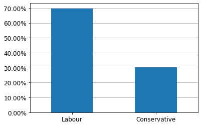

```python
import matplotlib.pyplot as pyp
fig = pyp.figure()
ax = fig.add_subplot(111)

counts.plot(ax=ax,kind='bar', stacked=True, rot=0)
vals = ax.get_yticks()
ax.set_yticklabels(['{:3.2f}%'.format(x*100) for x in vals])
ax.yaxis.grid(True)
ax.set_axisbelow(True)
pyp.show()
```

**Note:**

An imbalanced classification problem is an example of a classification problem where the distribution of examples across the known classes is biased or skewed.

The distribution can vary from a **slight bias** to a **severe imbalance** where there is one example in the minority class for hundreds, thousands, or millions of examples in the majority class or classes.

A classification problem may be a little skewed, such as if there is a slight imbalance. Alternately, the classification problem may have a severe imbalance where there might be hundreds or thousands of examples in one class and tens of examples in another class for a given training dataset.

**Slight Imbalance:** An imbalanced classification problem where the distribution of examples is uneven by a small amount in the training dataset **(e.g. 4:6 or 3:7)**.

**Severe Imbalance:** An imbalanced classification problem where the distribution of examples is uneven by a large amount in the training dataset **(e.g. 1:100 or more)**.

Here, we have **70%-30% distribution** and a **slight imbalance is often not a concern, and the problem can often be treated like a normal classification problem**.

**SO WE ARE PREOCEEDING `AS IS DISTRIBUTION` `(NOT PERFORMING SMOTE ON THIS DATASET)`**

```python
##  Function to calculate different metric scores of the model - Accuracy, Recall, Precision and F1-score
def get_metrics_score(model,flag=True):
    '''
    model : classifier to predict values of X

    '''
    # defining an empty list to store train and test results
    score_list=[]

    pred_train = model.predict(X_train)
    pred_test = model.predict(X_test)

    train_acc = model.score(X_train,y_train)
    test_acc = model.score(X_test,y_test)

    train_recall = metrics.recall_score(y_train,pred_train)
    test_recall = metrics.recall_score(y_test,pred_test)

    train_precision = metrics.precision_score(y_train,pred_train)
    test_precision = metrics.precision_score(y_test,pred_test)

    train_f1 = metrics.f1_score(y_train,pred_train)
    test_f1 = metrics.f1_score(y_test,pred_test)

    score_list.extend((train_acc,test_acc,train_recall,test_recall,train_precision,test_precision,train_f1,test_f1))

    # If the flag is set to True then only the following print statements will be dispayed. The default value is set to True.
    if flag == True:
        print("Accuracy on training set :{:.0%}".format(model.score(X_train,y_train)))
        print("Accuracy on test set : {:.0%}".format(model.score(X_test,y_test)))
        print("Recall on training set : {:.0%}".format(metrics.recall_score(y_train,pred_train)))
        print("Recall on test set : {:.0%}".format(metrics.recall_score(y_test,pred_test)))
        print("Precision on training set : {:.0%}".format(metrics.precision_score(y_train,pred_train)))
        print("Precision on test set : {:.0%}".format(metrics.precision_score(y_test,pred_test)))
        print("F1 score on training set : {:.0%}".format(metrics.f1_score(y_train,pred_train)))
        print("F1 score on test set : {:.0%}".format(metrics.f1_score(y_test,pred_test)))
    return score_list # returning the list with train and test scores
```

```python
## Function to create confusion matrix
def make_confusion_matrix(model,y_actual,labels=[1, 0]):
    '''
    model : classifier to predict values of X
    y_actual : ground truth

    '''
    y_predict = model.predict(X_test)
    cm=metrics.confusion_matrix( y_actual, y_predict, labels=[0, 1])
    df_cm = pd.DataFrame(cm, index = [i for i in ["Actual - No","Actual - Yes"]],
                  columns = [i for i in ['Predicted - No','Predicted - Yes']])
    group_counts = ["{0:0.0f}".format(value) for value in
                cm.flatten()]
    group_percentages = ["{0:.2%}".format(value) for value in
                         cm.flatten()/np.sum(cm)]
    labels = [f"{v1}\n{v2}" for v1, v2 in
              zip(group_counts,group_percentages)]
    labels = np.asarray(labels).reshape(2,2)
    plt.figure(figsize = (10,7))
    sns.heatmap(df_cm, annot=labels,fmt='')
    plt.ylabel('True label')
    plt.xlabel('Predicted label')
```

## Apply Logistic Regression and LDA (linear discriminant analysis). Interpret the results

### Logistic Regression

```python
from sklearn.linear_model import  LogisticRegression
```

```python
lr = LogisticRegression()
lr.fit(X_train, y_train)

train_pred = lr.predict(X_train)
test_pred = lr.predict(X_test)

print('Train Accuracy: {:.0%}'.format(accuracy_score(y_train, train_pred)))
print('Test Accuracy: {:.0%}'.format(accuracy_score(y_test, test_pred)))
print('\n')
print("Train Classification Report")
print('\n')
print(classification_report(y_train, train_pred))
print("Test Classification Report")
print('\n')
print(classification_report(y_test, test_pred))
```

```
Train Accuracy: 83%
Test Accuracy: 85%


Train Classification Report


              precision    recall  f1-score   support

           0       0.75      0.65      0.70       323
           1       0.86      0.91      0.88       744

    accuracy                           0.83      1067
   macro avg       0.80      0.78      0.79      1067
weighted avg       0.82      0.83      0.82      1067

Test Classification Report


              precision    recall  f1-score   support

           0       0.80      0.68      0.73       139
           1       0.87      0.92      0.90       319

    accuracy                           0.85       458
   macro avg       0.83      0.80      0.81       458
weighted avg       0.85      0.85      0.85       458
```

```python
#Using above defined function to get accuracy, recall, precision and F1-score on train and test set
lr_score=get_metrics_score(lr)
```

```
Accuracy on training set :83%
Accuracy on test set : 85%
Recall on training set : 91%
Recall on test set : 92%
Precision on training set : 86%
Precision on test set : 87%
F1 score on training set : 88%
F1 score on test set : 90%
```

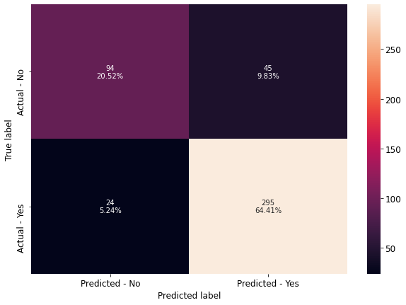

```python
make_confusion_matrix(lr,y_test)
```

```
AUC Training Data for Logistic Regression: 0.877
```

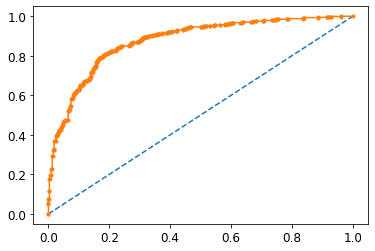

```
AUC Test Data for Logistic Regression: 0.914
```

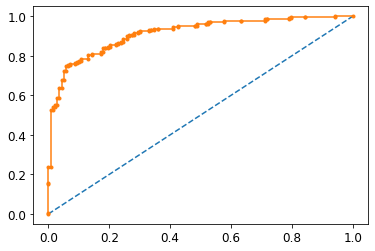

```python
# --------------------------------------------------------------------------------------------------------------------
# predict probabilities
probs_lr = lr.predict_proba(X_train)
# keep probabilities for the positive outcome only
probs_lr = probs_lr[:, 1]
# calculate AUC
auc_lr_train = roc_auc_score(y_train, probs_lr)
print('AUC Training Data for Logistic Regression: %.3f' % auc_lr_train)
# calculate ROC
fpr_lr_train, tpr_lr_train, thresholds_lr_train = roc_curve(y_train, probs_lr)
plt.plot([0, 1], [0, 1], linestyle='--')
# plot the roc curve for the model
plt.plot(fpr_lr_train, tpr_lr_train, marker='.')
# show the plot
plt.show()
# --------------------------------------------------------------------------------------------------------------------
# predict probabilities
probs_lr = lr.predict_proba(X_test)
# keep probabilities for the positive outcome only
probs_lr = probs_lr[:, 1]
# calculate AUC
auc_lr_test = roc_auc_score(y_test, probs_lr)
print('AUC Test Data for Logistic Regression: %.3f' % auc_lr_test)
# calculate ROC
fpr_lr_test, tpr_lr_test, thresholds_lr_test = roc_curve(y_test, probs_lr)
plt.plot([0, 1], [0, 1], linestyle='--')
# plot the roc curve for the model
plt.plot(fpr_lr_test, tpr_lr_test, marker='.')
# show the plot
plt.show()
```

```python
# defining list of models
models = [lr]

# defining empty lists to add train and test results
acc_train = []
acc_test = []
recall_train = []
recall_test = []
precision_train = []
precision_test = []
f1_train = []
f1_test = []

# looping through all the models to get the accuracy, precall and precision scores
for model in models:
    j = get_metrics_score(model,False)
    acc_train.append(np.round(j[0],2))
    acc_test.append(np.round(j[1],2))
    recall_train.append(np.round(j[2],2))
    recall_test.append(np.round(j[3],2))
    precision_train.append(np.round(j[4],2))
    precision_test.append(np.round(j[5],2))
    f1_train.append(np.round(j[6],2))
    f1_test.append(np.round(j[7],2))
```

```python
model_interpretation_frame = pd.DataFrame({'Model':['Logistic Regression'],
                                          'Train_Accuracy': acc_train,'Test_Accuracy': acc_test,
                                          'Train_Recall':recall_train,'Test_Recall':recall_test,
                                          'Train_Precision':precision_train,'Test_Precision':precision_test,
                                          'Train_F1 score':f1_train,'Test_F1 score':f1_test})
model_interpretation_frame
```

|  | Model | Train_Accuracy | Test_Accuracy | Train_Recall | Test_Recall | Train_Precision | Test_Precision | Train_F1 score | Test_F1 score |
| --- | --- | --- | --- | --- | --- | --- | --- | --- | --- |
| 0 | Logistic Regression | 0.83 | 0.85 | 0.91 | 0.92 | 0.86 | 0.87 | 0.88 | 0.9 |

**Intepretation:**

**Logistic regression:**

- Accuracy for train and test is **almost same** (i.e. train: ~83%, test: ~85%)
- Recall for train and test is **almost same** (i.e. train: ~91%, test: ~92%)
- Precision for train and test is **almost same** (i.e. train: ~86%, test: ~87%)
- F1-score for train and test is **almost same** (i.e. train: ~88%, test: ~90%)
- AUC for train and test is **almost same** (i.e. train: ~88%, test: ~91%)

Let's evaluate other models